# White wine data EDA

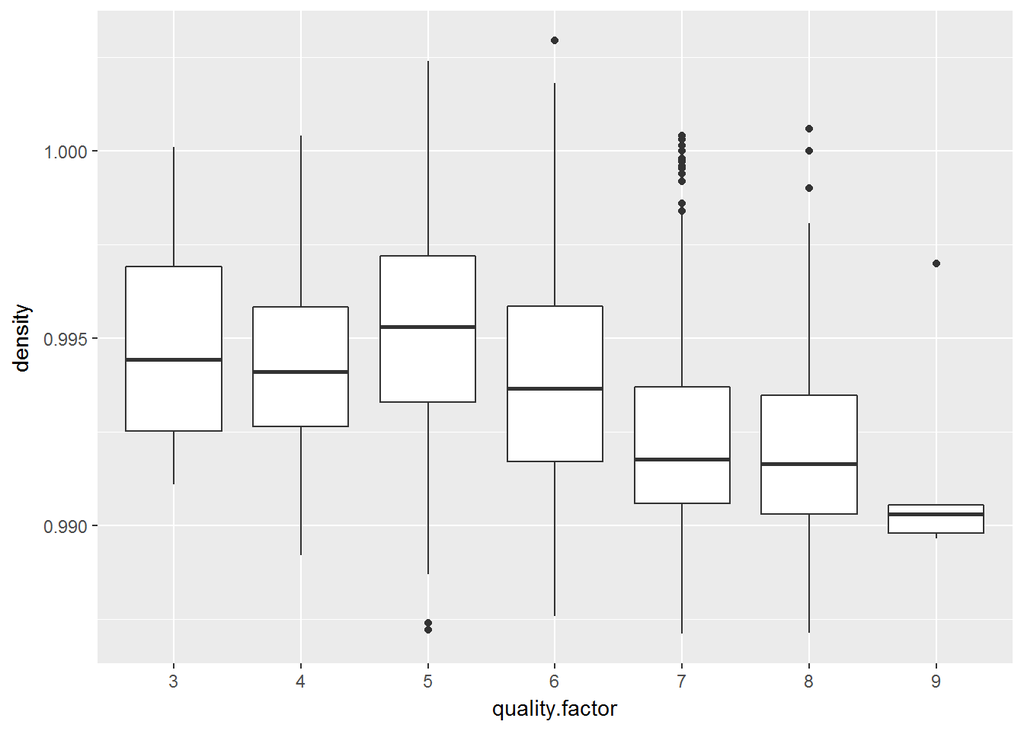

From this density vs quality plot, wines with quality greater than 6 generally have lower density. Since alcohol density is less than water, wines with more alcohol have lower density and higher quality.

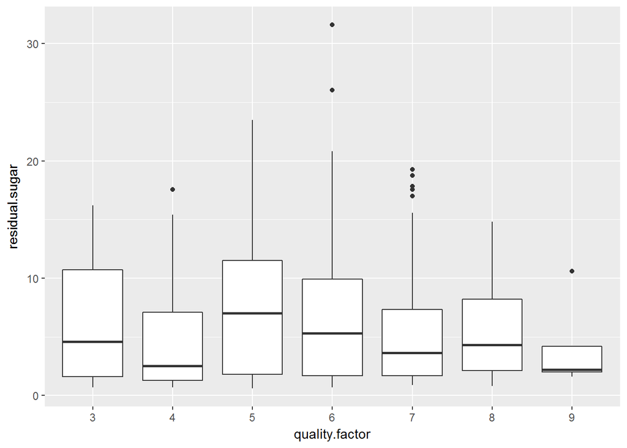

From this residual suagr vs quality plot, it is hard to tell any relation in it. But the highest quality wine have the slightest residual residual sugar.

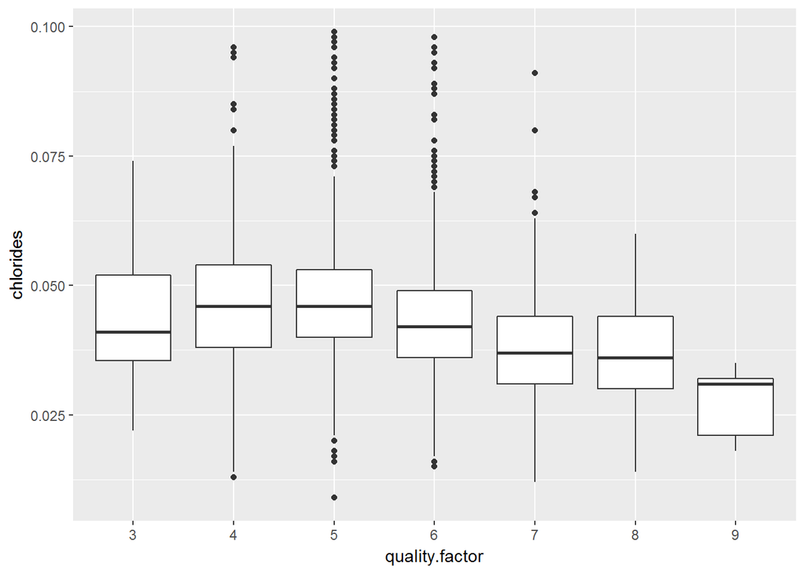

From this chlorides vs quality plot, it just have a little downward trend when quality inceasing.

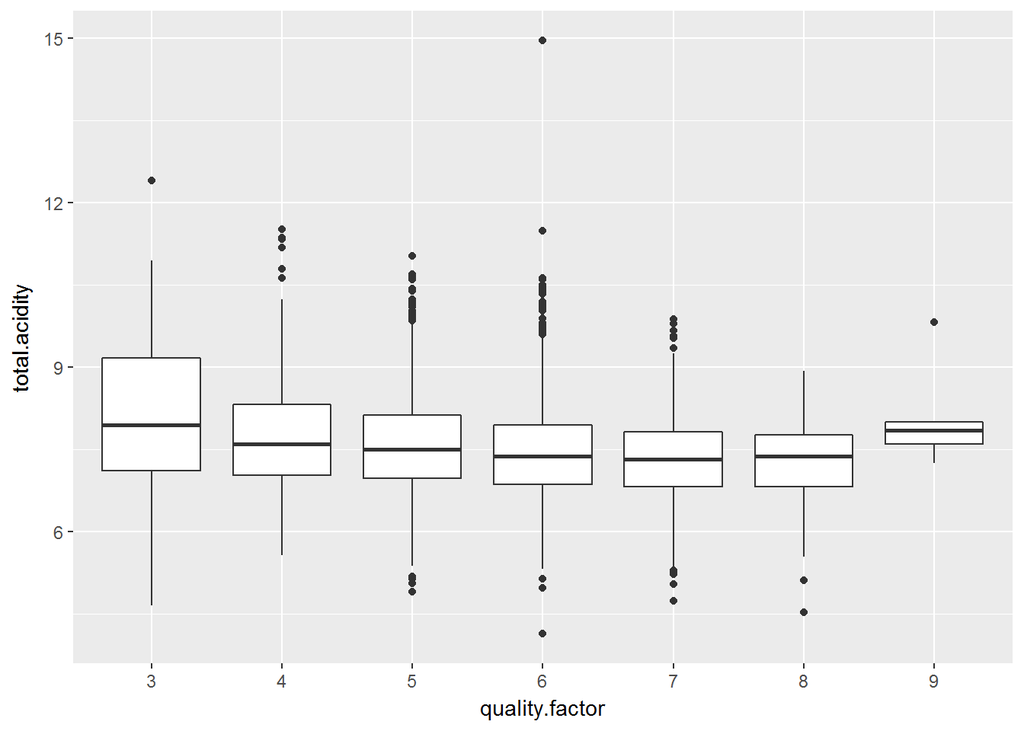

From this total acidity vs quality plot, I couldn’t see any relation from this boxplot.

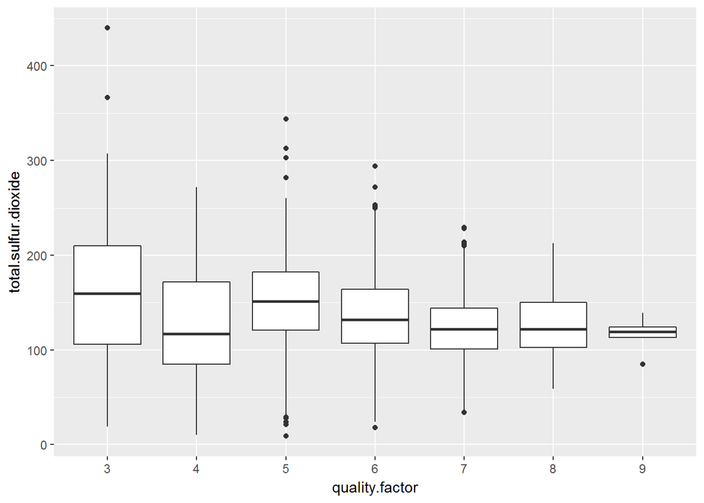

I couldn’t any relation from this boxplot. All the above boxplots are some how related to quality. Next, I will explore some other interesting features.

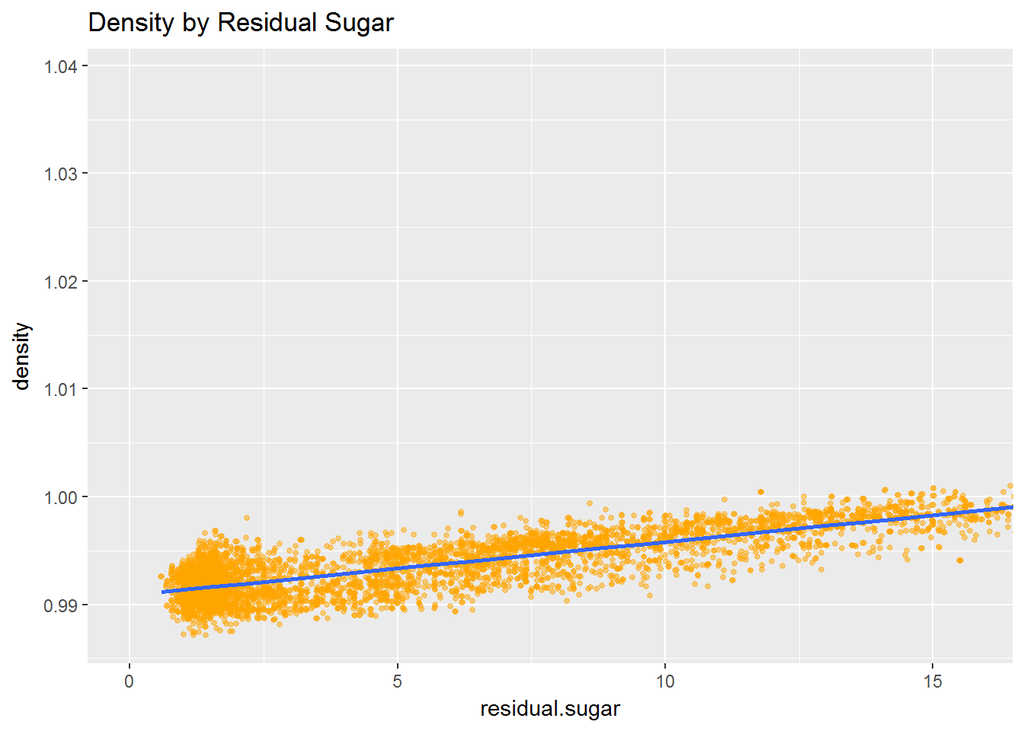

Residual sugar and density have 0.84 correlation. This is verified from this plot. I think this is because sugar solvent has higher density.

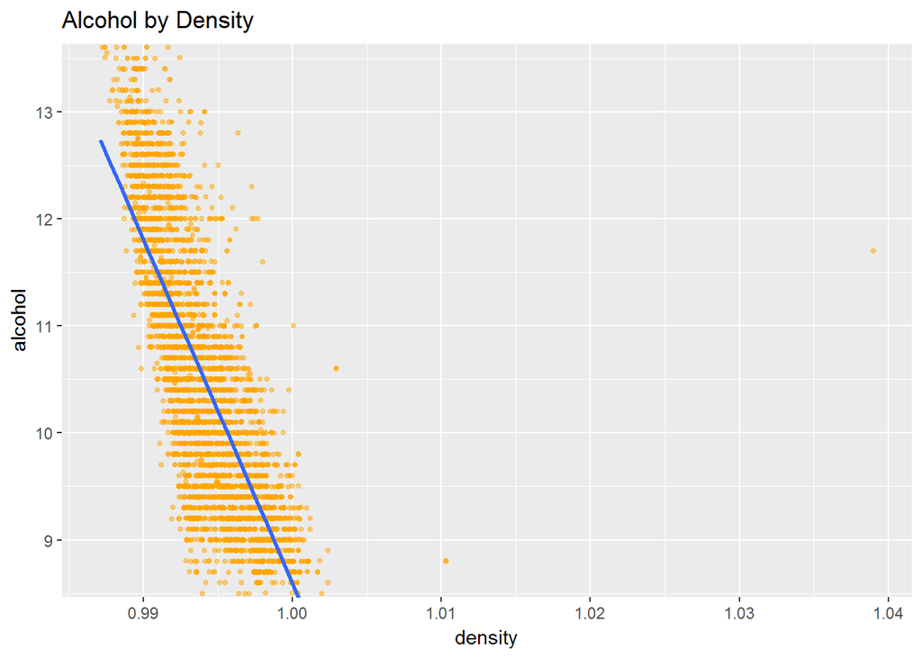

Also, a strong relationship between density and alcohol is verified. Their correlation is -0.78.

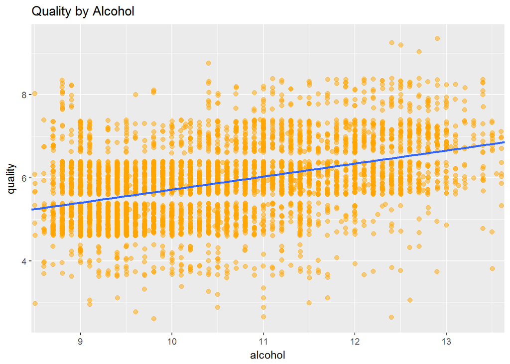

From alcohol and quality boxplot, I thought they should have a relation. So I made this scatter plot to verify it.

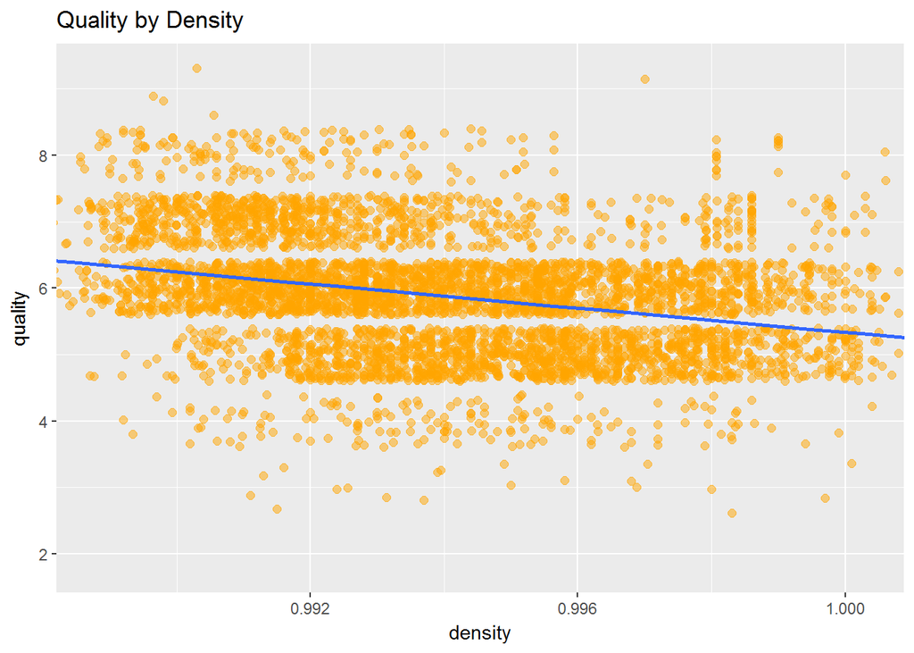

Also, I made this quanlity VS density scatter plot to verify my thought from their boxplot.

# Bivariate Analysis

### Talk about some of the relationships you observed in this part of the investigation. How did the feature(s) of interest vary with other features in the dataset?

I observed quality vs alcohol and quality vs density since quality is the main interest of this dataset. Alcohol has 0.44 correlation wieh quality while density has -0.31. But alcohol and density are somehow related because alcohol has smaller densidy than water.

For other features, I couldn’t any significant relations with quality.

### Did you observe any interesting relationships between the other features (not the main feature(s) of interest)?

Density generall has relation with all ingredients(acid, sugar, sodium).

### What was the strongest relationship you found?

The strongest relationship is between density and residual sugar(0.84). The second one is density with alcohol (-0.78) .

# Multivariate Plots Section

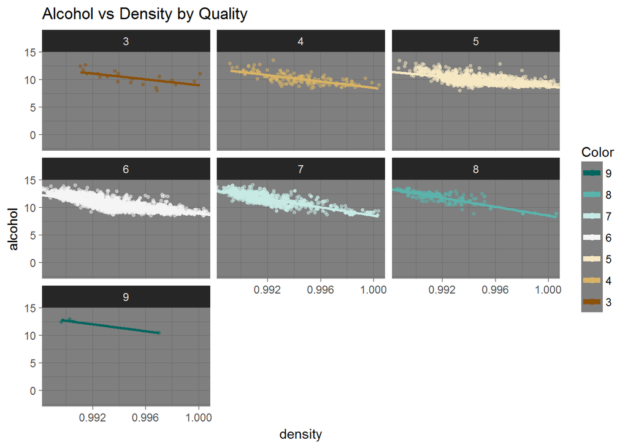

Facet Alcohol vs Density scatter plots by Quality. I can see the distribution move from bottom-right to top-left when quality increasing.

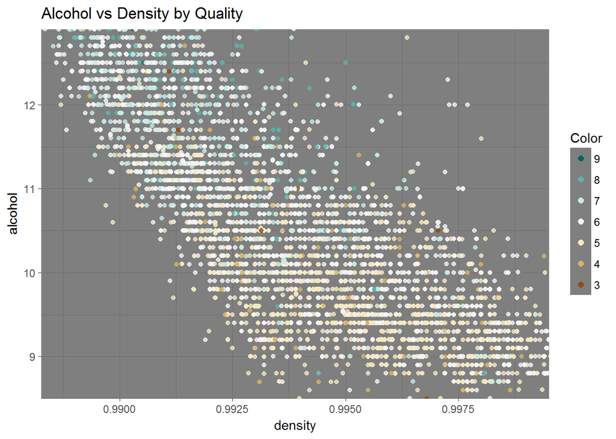

Scatter plot Alcohol vs Density scatter plots by Quality. I can clearly see the negative correlation between Alcohol and Density, and the positive correlation between Quality and Alcohol.

```
##
## (7.9,9]  (9,10] (10,11] (11,12] (12,13] (13,14] (14,15]
##     502    1583    1252     850     609     100       2
```

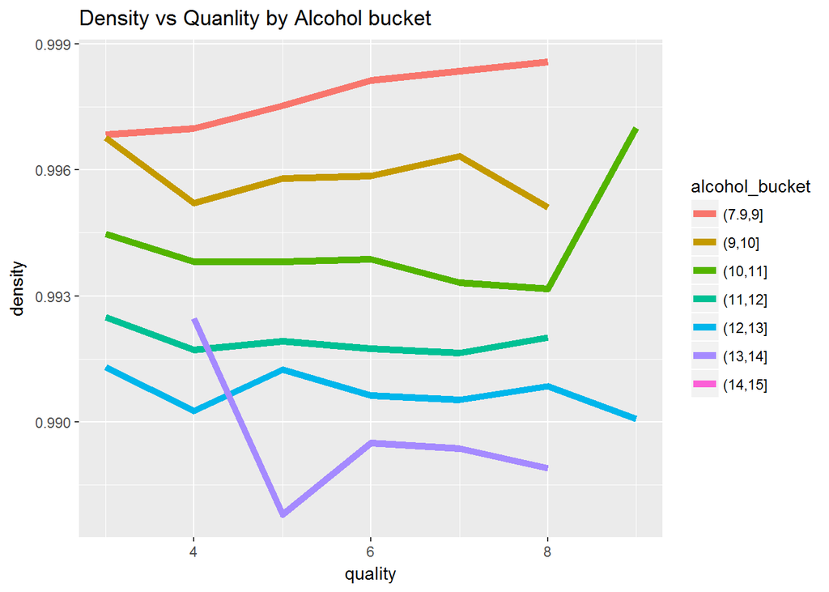

Made alcohol feature bucket c(7.9, 9.0, 10.0, 11.0, 12.0, 13.0 ,14.0, 15.0), and used it to plot mean of Density VS Quality. I can clearly see the relation between density and alcohol as I talked above.

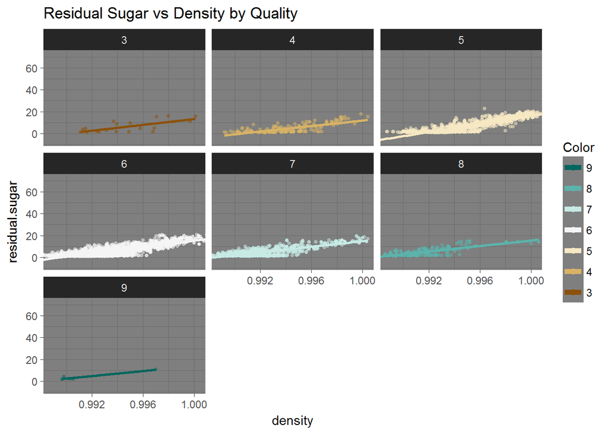

Facet Residual Sugar vs Density scatter plots by Quality. I can see the distribution move from bottom-right to bottom- left when quality increasing.

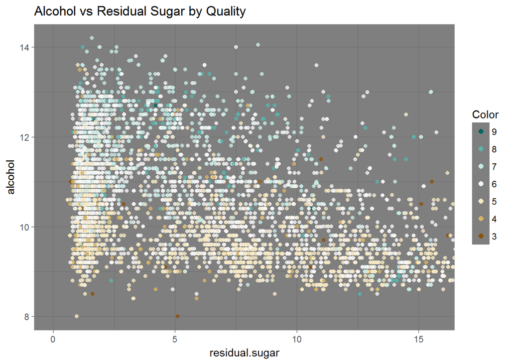

Scatter plot Alcohol vs Residual sugar by Quality. I can see the quality distribution when alcohol increasing.

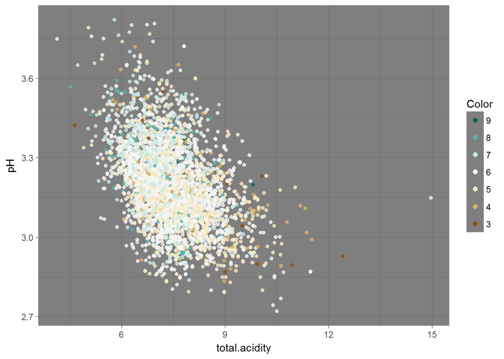

```
## $title
## [1] "PH vs total.acidity by Quality"
##
## $subtitle
## NULL
##
## attr(,"class")
## [1] "labels"
```

Since acid should be related with PH value, I want to investgate if PH related to quality. From this plot, I can see the negative relation between PH and Total.acidity. But I couldn’t see any relation between PH and Quality.

```
##
## Calls:
## m1: lm(formula = quality ~ residual.sugar, data = wines)
## m2: lm(formula = quality ~ residual.sugar + chlorides, data = wines)
## m3: lm(formula = quality ~ residual.sugar + chlorides + alcohol,
##     data = wines)
## m4: lm(formula = quality ~ residual.sugar + chlorides + alcohol +
##     total.sulfur.dioxide, data = wines)
## m5: lm(formula = quality ~ residual.sugar + chlorides + alcohol +
##     total.sulfur.dioxide + density, data = wines)
## m6: lm(formula = quality ~ residual.sugar + chlorides + alcohol +
##     total.sulfur.dioxide + density + total.acidity, data = wines)
##
## ============================================================================================================
##                              m1            m2            m3            m4            m5            m6
## ------------------------------------------------------------------------------------------------------------
##   (Intercept)               5.987***      6.343***      2.276***      2.283***     91.324***     63.368***
##                            (0.020)       (0.032)       (0.135)       (0.153)      (12.672)      (14.598)
##   residual.sugar           -0.017***     -0.014***      0.021***      0.021***      0.052***      0.043***
##                            (0.002)       (0.002)       (0.003)       (0.003)       (0.005)       (0.006)
##   chlorides                              -8.224***     -2.062***     -2.058***     -1.819**      -1.883***
##                                          (0.567)       (0.556)       (0.558)       (0.556)       (0.555)
##   alcohol                                               0.339***      0.339***      0.237***      0.267***
##                                                        (0.011)       (0.012)       (0.018)       (0.020)
##   total.sulfur.dioxide                                               -0.000         0.000         0.000
##                                                                      (0.000)       (0.000)       (0.000)
##   density                                                                         -88.779***    -60.468***
##                                                                                   (12.634)      (14.611)
##   total.acidity                                                                                  -0.057***
##                                                                                                  (0.015)
## ------------------------------------------------------------------------------------------------------------
##   R-squared                 0.010         0.050         0.204         0.204         0.212         0.215
##   adj. R-squared            0.009         0.050         0.204         0.204         0.211         0.214
##   sigma                     0.882         0.863         0.790         0.790         0.787         0.785
##   F                        47.064       129.783       418.558       313.857       263.444       222.614
##   p                         0.000         0.000         0.000         0.000         0.000         0.000
##   Log-likelihood        -6331.187     -6228.081     -5795.291     -5795.287     -5770.691     -5763.313
##   Deviance               3804.419      3647.571      3056.715      3056.709      3026.163      3017.060
##   AIC                   12668.375     12464.161     11600.583     11602.574     11555.381     11542.625
##   BIC                   12687.865     12490.147     11633.066     11641.553     11600.858     11594.598
##   N                      4898          4898          4898          4898          4898          4898
## ============================================================================================================
```

```
##
## Call:
## lm(formula = quality ~ residual.sugar + chlorides + alcohol +
##     total.sulfur.dioxide + density + total.acidity, data = wines)
##
## Residuals:
##     Min      1Q  Median      3Q     Max
## -3.4989 -0.5371 -0.0066  0.4717  3.2719
##
## Coefficients:
##                        Estimate Std. Error t value Pr(>|t|)
## (Intercept)           6.337e+01  1.460e+01   4.341 1.45e-05 ***
## residual.sugar        4.256e-02  5.675e-03   7.499 7.57e-14 ***
## chlorides            -1.883e+00  5.555e-01  -3.390 0.000703 ***
## alcohol               2.667e-01  1.998e-02  13.347  < 2e-16 ***
## total.sulfur.dioxide  3.683e-04  3.139e-04   1.173 0.240777
## density              -6.047e+01  1.461e+01  -4.139 3.55e-05 ***
## total.acidity        -5.681e-02  1.479e-02  -3.842 0.000124 ***
## ---
## Signif. codes:  0 '***' 0.001 '**' 0.01 '*' 0.05 '.' 0.1 ' ' 1
##
## Residual standard error: 0.7854 on 4891 degrees of freedom
## Multiple R-squared:  0.2145, Adjusted R-squared:  0.2135
## F-statistic: 222.6 on 6 and 4891 DF,  p-value: < 2.2e-16
```

Fit linear model using residual sugar, chlorides, alcohol, total.sulfur.dioxide, density and total.acidity predictor.

# Multivariate Analysis

### Talk about some of the relationships you observed in this part of the investigation. Were there features that strengthened each other in terms of looking at your feature(s) of interest?

In this multivariate analysis section, I kept further investigating relation in alcohol, residual sugar, density and output feature quality. All these plots strenthened my thought from section 2.

### OPTIONAL: Did you create any models with your dataset? Discuss the strengths and limitations of your model.

I built a linear model trying to predict by useing 6 features: residual sugar, chlorides, alcohol, total.sulfur.dioxide,density and total.acidity. But I only got ‘Multiple R-squared: 0.2145, Adjusted R-squared: 0.2135’ which is not accurate enough. ——

# Final Plots and Summary

### Plot One

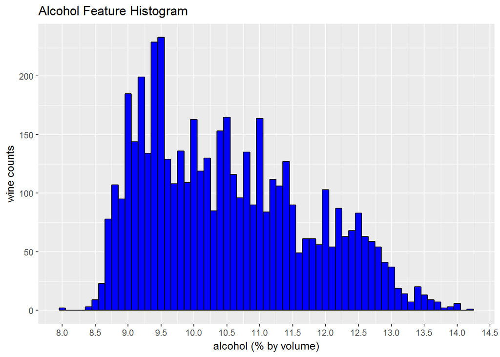

```
##    Min. 1st Qu.  Median    Mean 3rd Qu.    Max.
##    8.00    9.50   10.40   10.51   11.40   14.20
```

### Description One

The distribution of alcohol is a little bit right skewed. This feature has no outliers. Most of wines have less than 11.0 (% by volume) alcohol.

### Plot Two

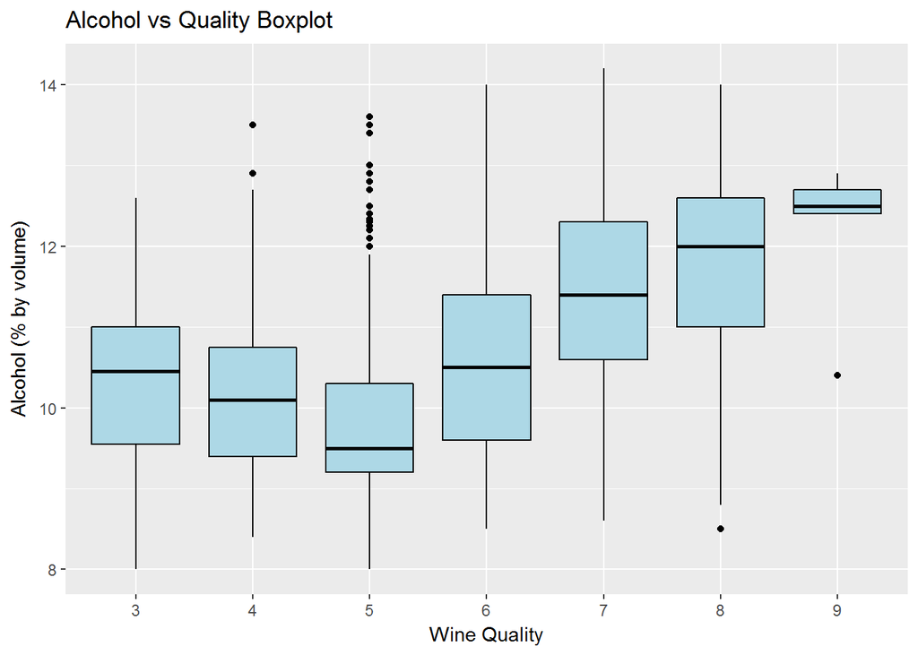

### Description Two

difficult to tell any relation for wines’ quality less than 6.

### Plot Three

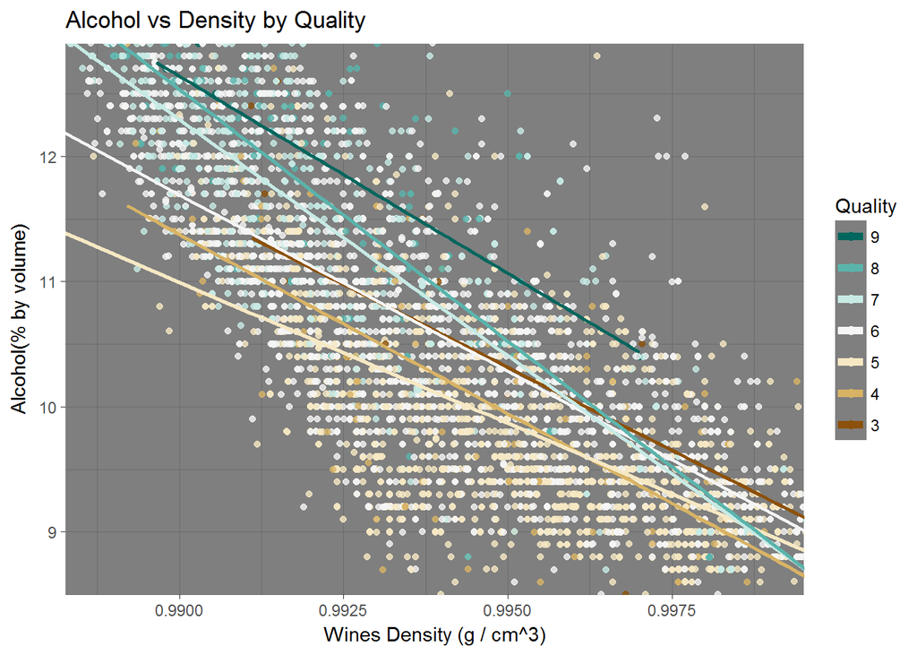

### Description Three

The negative correlation between alcohol and density is clearly observed. Since the mid quality is in color white, it is easier to observe that higher quality wines tend to have more alcohol, and vise versa.

# Reflection

There are 4898 wines infomation in this wine dataset. Before I investigate this dataset, I managed to acquire some knowledge from internet to deeply understand these features in it.Basicly, Sweet Taste (sugars + alcohols) and Acid Taste(acids) determine the quality of wines.Then I create histogram for each feature to understand features. The main interest of this dataset is quality. I found several features might have relations with it: alcohol, sugar, density, acid,etc. The most interesting feature for me is alcohol. Then I focused on relations in main interest,alcohol and other features.

I found density almost has strong relation to all features. This is reasonable since all content in wines can affect density. I also found PH value is highly related with acid. The most interesting part I found is high quality wines tend to have high content of alcohol.

Then I built a linear model to predict. Unfortunately, the accuracy is not good enough. I will try to build some other regression model(e.g., support vector machine(SVM)) to enhance the accuracy.

# Bibliography

https://en.wikipedia.org/wiki/Sodium_chloride#Chemistry

http://www.calwineries.com/learn/wine-chemistry